# Classifying the Quality of a Weight Lifting Acitivity

A Coursera Student

December 27, 2015

#### **Background**

As displayed here, the raw training data consists 19,622 observations where each observation is composed of 160 features/covariates. Six Partipants were asked to perform the Unilateral Dubbell Biceps Curl in five different ways. Our task was to build a predictive model that can accurately classify the five ways in which the dubbell biceps curl was performed based on a given set of features.

```r
rawData <- read.csv(file='./data/pml-training.csv', na.strings=c(""," ","NA"))
dim(rawData); table(rawData$classe); table(rawData$user_name)
```

```
## [1] 19622   160
```

```
##
##    A    B    C    D    E
## 5580 3797 3422 3216 3607
```

```
##
##   adelmo carlitos  charles   eurico   jeremy    pedro
##     3892     3112     3536     3070     3402     2610
```

#### **Data Cleaning and Preprocessing**

The main aim of the data cleaning was to remove any unneccessary covariates as many as possible to build a robust and efficient model with minimum level of noise and overfitting. First, the covariates that are nearly entirely filled by ‘NA’ or ’’ were removed to avoid any unnecessary data imputation that can only lead to worsening of bias and variance.

```r
covNames <- names(rawData)
cov_na <- colSums(is.na(rawData)) >= ceiling(dim(rawData)[1] * 0.8)
rawData_adj <- rawData[, !cov_na]
```

Afterwards, the remaining covariates were evaluated in order to remove any covariates with near zero variabilities that would not contribute much in building a predictive model.

```r
nsv <- nearZeroVar(rawData_adj, saveMetrics=TRUE)
#names(rawData_adj)[nsv$nzv==TRUE]
rawData_adj <- rawData_adj[,!nsv$nzv==TRUE]
```

```r
cov_drop <- c("X", "user_name", "cvtd_timestamp")
rawData_cleaned <- rawData_adj[ , !(names(rawData_adj)) %in% cov_drop]
covariates_kept <- names(rawData_cleaned)
```

The remaining covariates at this point were then centered and scaled based on their respective covariate mean and standard deviation so that the model’s prediction is not biased by covariates with values that deviates in quantity unit relative to the quantity unit of the other covariates.

```r
preObj <- preProcess(rawData_cleaned[,-57], method=c("center", "scale"))
rawData_cleaned <- predict(preObj, rawData_cleaned)
```

Further, a paired correlation plot was generated with the remaining covariates to check if there exists any covariates with high level of correlation. Here, a pair of covariates with correlation value equal to or greater than 0.9 was considered as a high level.

```r
M <- abs(cor(as.data.frame(lapply(rawData_cleaned[,-57], as.numeric))))
diag(M) <- 0
which(M > 0.9, arr.ind=T)
```

```
##                  row col
## total_accel_belt   7   4
## accel_belt_y      12   4
## accel_belt_z      13   4
## accel_belt_x      11   5
## roll_belt          4   7
## accel_belt_y      12   7
## accel_belt_z      13   7
## pitch_belt         5  11
## roll_belt          4  12
## total_accel_belt   7  12
## accel_belt_z      13  12
## roll_belt          4  13
## total_accel_belt   7  13
## accel_belt_y      12  13
## gyros_arm_y       22  21
## gyros_arm_x       21  22
## gyros_dumbbell_z  36  34
## gyros_forearm_z   49  34
## gyros_dumbbell_x  34  36
## gyros_forearm_z   49  36
## gyros_dumbbell_x  34  49
## gyros_dumbbell_z  36  49
```

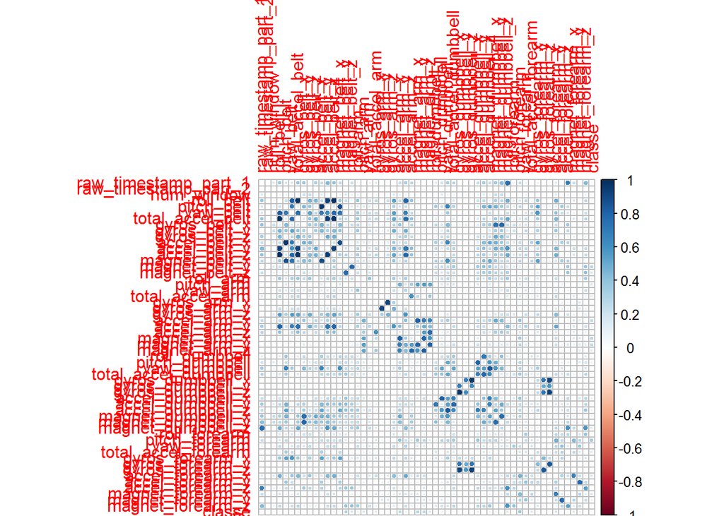

```r
corrplot(M, method="circle")
```

As indicated by the large and dark blue circles in the plot, there exist many covariates with high levels of correlations. This meant that the dimension of the current dataset could be further reduced with PCA (Principle Component Analysis). The parameter of the PCA was set so to reduce the dimentionality while retaining the 98% of the variance existing in the dataset.

```r
set.seed(1111)
preProc <- preProcess(rawData_cleaned[,-57], method="pca", thresh=0.98)
preProc$numComp
```

```
## [1] 33
```

```r
rawData_cleaned <- predict(preProc, rawData_cleaned)
```

After the completion of data cleaning and preprocessing procedure, there were approximately 80% reduction in the initial feature dimension. Here is the dimension of the dataset including the outcome feature.

```r
dim(rawData_cleaned)[2]
```

```
## [1] 34
```

#### **Training and Testing**

The cleaned dataset was split into two partitions, training and testing datasets. Here, 75% of the cleaned dataset was distributed to the training dataset while the remaining 25% was used as the test dataset.

```r
inTrain <- createDataPartition(y=rawData_cleaned$classe,
                               p=0.75, list=F)
trainSet <- rawData_cleaned[inTrain,]
testSet <- rawData_cleaned[-inTrain,]
```

The obtained trainSet was used to build a predictive model using *BAGGING (Bootstrap Aggregating)* with inference regression trees. In general, the BAGGING uses bootstrap sampling method (sampling with replacement) to build multiple models based on different training datasets. A final classified output is based on majority voting of the multiple outputs resulting from the multiple predictive models.

```r
X<-subset(trainSet, select=-c(classe))
Y<-trainSet$classe
treebag <- bag(X,Y,B=20,
               bagControl=bagControl(
                 fit=ctreeBag$fit,
                 predict=ctreeBag$pred,
                 aggregate=ctreeBag$aggregate
               )
)
```

The built model was used on the pseudo-test dataset to get a basic out of sample error estimate. The observed accuracy is shown here.

```r
predicted <- predict(treebag, subset(testSet, select=-c(classe)))
t = table(predicted == testSet$classe)
as.numeric( t[2]/sum(t) )
```

```
## [1] 0.9298532
```

```r
K=10
folds <- createFolds(testSet$classe, k=K, list=TRUE, returnTrain=FALSE)
miss_class <- rep(-1, K)

for (i in 1:K) {
  #obtain train and test set
  trSet <- testSet[-folds[[i]], ]
  ttSet <- testSet[folds[[i]], ]

  #fit a model
  x<-subset(trSet, select=-c(classe))
  y<-trSet$classe
  fitModel_bag <- bag(x,y,B=20,
                    bagControl=bagControl(
                    fit=ctreeBag$fit,
                    predict=ctreeBag$pred,
                    aggregate=ctreeBag$aggregate
                  )
  )

  #test the model
  true_output <- ttSet$classe
  ttSet <- subset(ttSet, select=-c(classe))
  modelPre <- predict(fitModel_bag, newdata=ttSet)

  #record misclassification rate
  ms <- sum((true_output == modelPre)*1)/length(modelPre)
  miss_class[i] <- ms

  as.character(ms)
}
sum(miss_class)/length(miss_class)
```

```
## [1] 0.8250386
```

#### **Predicting the New Dataset**

Finally, the built model was used to predict the given 20 test cases. The same PCA object and scale & center object used in the training procedure was applied to the new case in order to ensure no contamination.

```r
#Loading the raw data
testData_raw <- read.csv(file='./data/pml-testing.csv', na.strings=c(""," ","NA"))
dim(testData_raw)
```

```
## [1]  20 160
```

```r
testData_raw <- subset(testData_raw, select=covariates_kept[-56])
#scaled
testData_cleaned <- predict(preObj, testData_raw)
#PCA
testData_cleaned <- predict(preProc, testData_cleaned)

#Predict
predict(treebag, testData_cleaned)
```

```
##  [1] B A A A A E D B A A B C B A E E A B B B
## Levels: A B C D E
```

When the result was submitted to the course website for validation, the classified outputs were correct 19 out 20 times.